# Amlodipine in AGS gastric cancer cells: an RNA-seq reanalysis

Author

Published

October 13, 2026

## Summary

Amlodipine (5 µM, 48 h) produces a strong, reproducible transcriptional response in AGS gastric cancer cells. Treatment is the dominant source of variation between samples, and 2980 genes pass the significance thresholds. The response is dominated by activation of p53 target genes and suppression of cell-cycle programmes, alongside increased expression of mitochondrial energy metabolism genes. TKT, which the original study proposed as a mediator of amlodipine’s effects, is modestly lower at the mRNA level but does not reach significance. The transcriptome alone therefore neither confirms nor rules out a TKT-centred mechanism.

## Background

AGS gastric adenocarcinoma cells were treated with 5 µM amlodipine or DMSO vehicle for 48 h, with three biological replicates per group (GSE348880). The original study proposed that amlodipine’s anti-tumour effect involves altered pentose phosphate pathway (PPP) activity mediated by transketolase (TKT). This report reanalyses the raw sequencing data to see what the transcriptome shows, both genome-wide and for the PPP specifically.

## Methods in brief

Reads were downloaded from SRA, checked with FastQC and MultiQC, and quantified with Salmon against the GENCODE release 50 human transcriptome. Transcript estimates were summarised to genes with tximport. Structural RNA biotypes (rRNA, snRNA, snoRNA and others) and low-count genes were removed before differential expression analysis with DESeq2 (design `~ condition`), with apeglm fold-change shrinkage. Genes with padj < 0.05 and |log2FC| > 1 were called differentially expressed. Pathway analysis used GO over-representation (all tested genes as background) and GSEA on the DESeq2 Wald statistic against GO Biological Process, MSigDB Hallmark, and two custom PPP gene sets. The full workflow is available on [GitHub](https://github.com/SometimesJade/rna-seq-pipeline).

## Sample quality

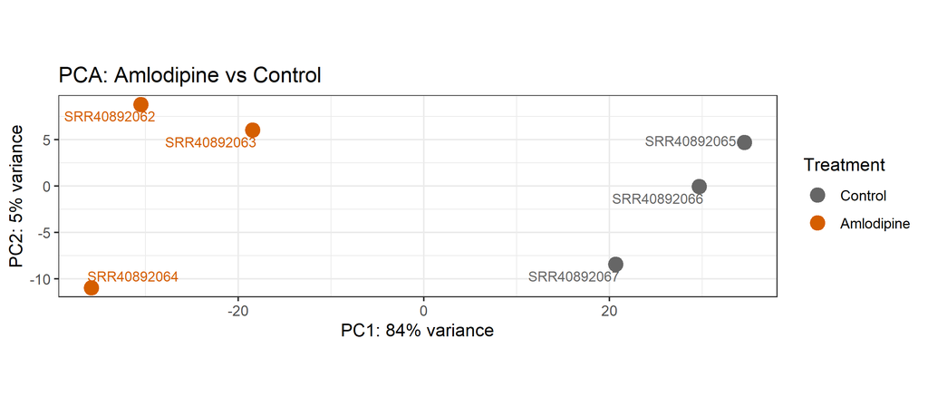

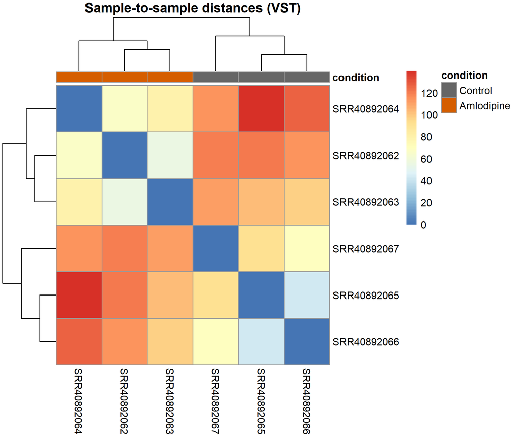

## Differential expression

At padj < 0.05 and |log2FC| > 1, 1977 genes are upregulated and 1003 are downregulated.

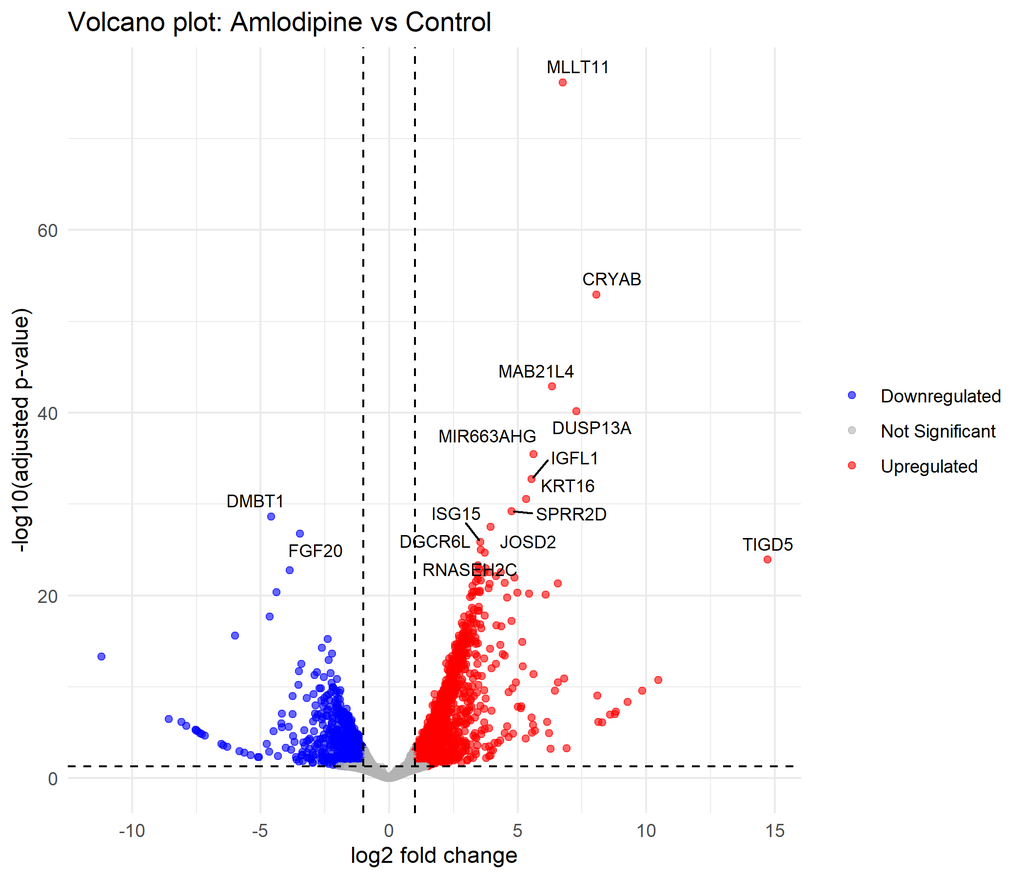

Top 10 DE genes by adjusted p-value

| symbol | baseMean | log2FoldChange | padj |
| --- | --- | --- | --- |
| MLLT11 | 1509.854 | 6.751 | 0 |
| CRYAB | 1144.742 | 8.066 | 0 |
| MAB21L4 | 4775.120 | 6.342 | 0 |
| DUSP13A | 496.112 | 7.280 | 0 |
| MIR663AHG | 488.708 | 5.615 | 0 |
| IGFL1 | 1556.327 | 5.545 | 0 |
| KRT16 | 319.279 | 5.330 | 0 |
| SPRR2D | 290.858 | 4.758 | 0 |
| DMBT1 | 1352.922 | -4.594 | 0 |
| JOSD2 | 3802.336 | 3.944 | 0 |

Among the most significant changes are several stress-responsive genes, including the small heat-shock protein CRYAB, the stress keratin KRT16 and the interferon-stimulated gene ISG15 .

## Pathways

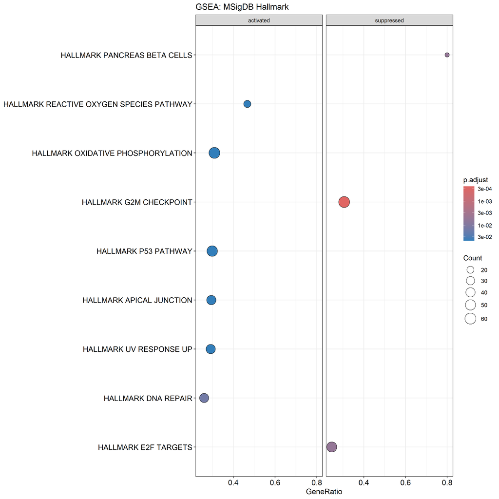

Significant Hallmark gene sets

| ID | setSize | NES | p.adjust |
| --- | --- | --- | --- |
| PANCREAS_BETA_CELLS | 15 | -2.140 | 0.005 |
| G2M_CHECKPOINT | 196 | -1.724 | 0.000 |
| E2F_TARGETS | 199 | -1.497 | 0.005 |
| P53_PATHWAY | 181 | 1.443 | 0.043 |
| OXIDATIVE_PHOSPHORYLATION | 197 | 1.452 | 0.043 |
| UV_RESPONSE_UP | 134 | 1.470 | 0.043 |
| APICAL_JUNCTION | 136 | 1.494 | 0.043 |
| DNA_REPAIR | 146 | 1.578 | 0.014 |
| REACTIVE_OXYGEN_SPECIES_PATHWAY | 45 | 1.659 | 0.043 |

## Does the data support a TKT-mediated PPP effect?

GSEA for PPP branches

| ID | setSize | NES | pvalue | core_enrichment |
| --- | --- | --- | --- | --- |
| PPP_nonoxidative | 4 | -1.194 | 0.292 | RPE/TKT/RPIA |
| PPP_oxidative | 4 | 1.030 | 0.486 | PGLS |

The non-oxidative PPP branch trends downward (NES -1.19, p = 0.29), with TKT among the leading-edge genes, while the oxidative branch shows no consistent change (NES 1.03, p = 0.49). Neither gene set is significant, and with only four genes per set after filtering, GSEA has little power to detect modest shifts.

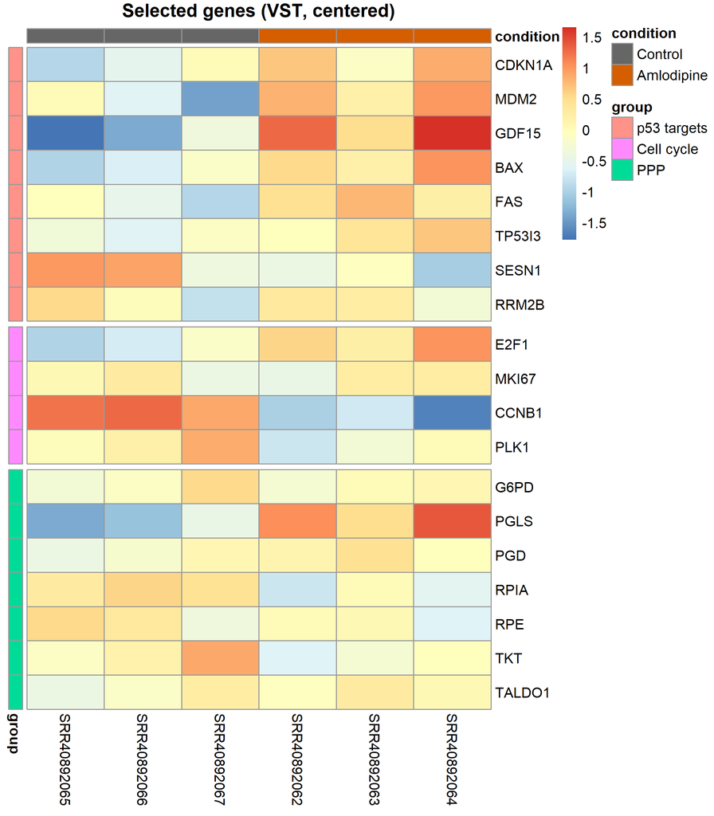

At the transcript level, the data are directionally consistent with reduced non-oxidative PPP activity, but they do not establish it. This does not contradict the original study: changes in transketolase could act through protein abundance, enzyme activity or metabolic flux, none of which RNA-seq measures. Since the PPP is a major source of NADPH for antioxidant defence, its relationship to the activated ROS pathway signature would be worth following up. Testing the TKT hypothesis directly would require protein or metabolic data, such as TKT immunoblotting or ¹³C-glucose tracing.

## Limitations

- Three replicates per group give limited power for modest effects such as the TKT change.
- A single cell line, dose and time point were profiled, so dose–response and timing effects cannot be assessed.
- RNA-seq measures transcript levels only; protein abundance, enzyme activity and metabolic flux are not captured.
- The library preparation is not stated in GEO. Poly-A selection was inferred from the absence of non-polyadenylated histone mRNAs.
- Processing differs from the original authors’ pipeline, so gene-level results may not match theirs exactly.